# 4.3: Generalized Linear Models

### Unit 4: Fisheries

#### Lesson 3: Generalized linear models

#### New skills: glm(family=“binomial”), glm(family=“poisson”), AER::dispersiontest, glm(family=“quasipoisson”)

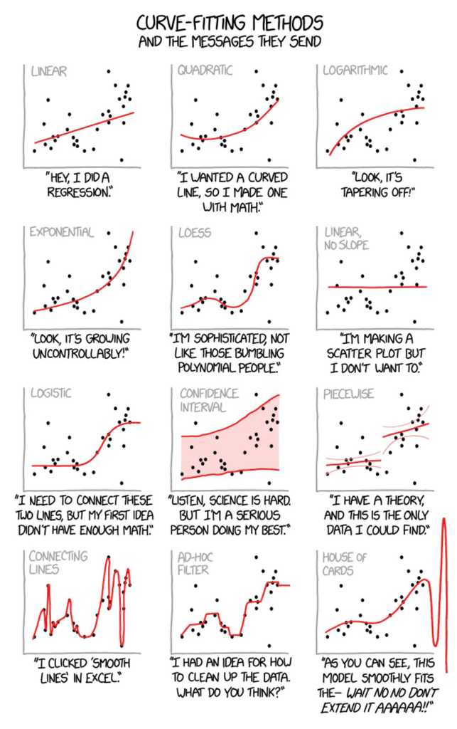

### Exploring fisheries data with GLMs

In this lesson we will continue to use the RAM Legacy Database:

https://www.ramlegacy.org/

```r
load('data/RAMLDB v4.66/R Data/DBdata[asmt][v4.66].RData')
```

First I’m going to import the code for the `collapse` table we built in the last class. That way I can use the data manipulation work we’ve already done as a basis for running our models today. I just put the code used to generate this tables in its own R script, and now I use the `source()` function to run that R script and bring the associated variables into my environment. Alternatively you could just copy and paste the code from the R script `build_collapse_table.R` into this script.

```r
source('build_collapse_table.R')
```

### Logistic regression

Logistic regression is used to model a binary dependent variable or a dependent variable that is bound between 0 and 1:

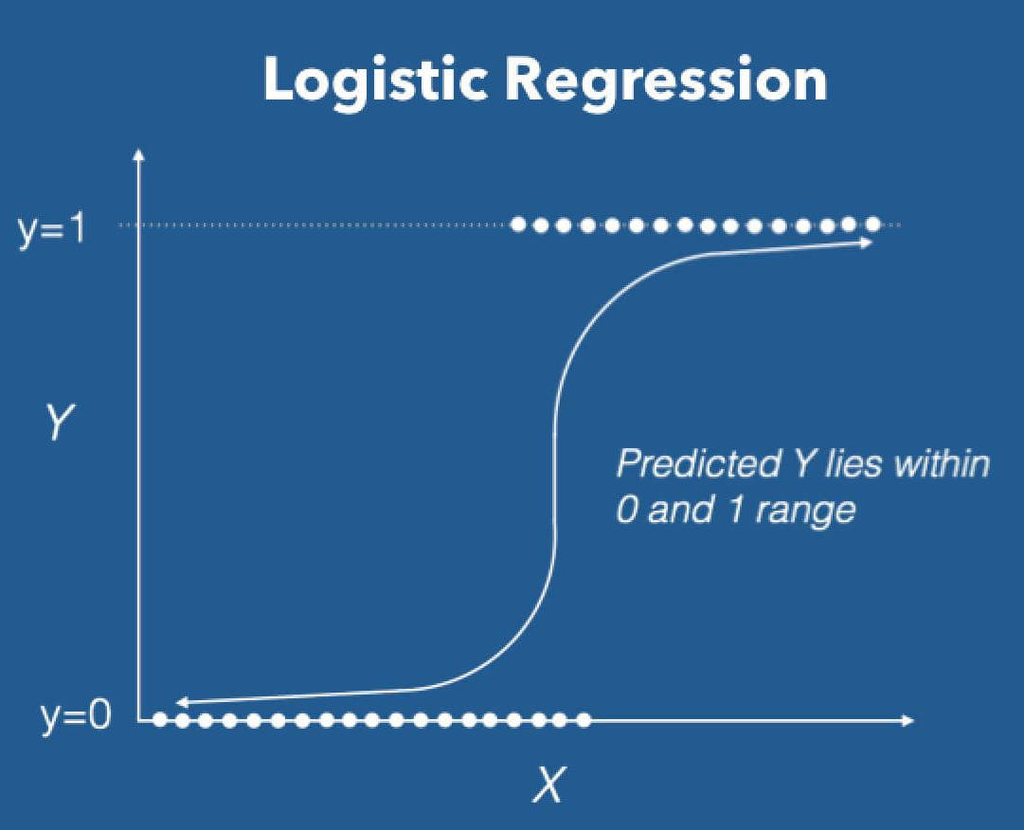

This is the logistic regression function where p(x) is our y variable, bounded between 0 and 1:

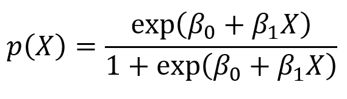

Although this equation doesn’t look like a linear equation, a logistic function is a generalized linear model because the model is *linear in the predictors*, meaning that the model is fit to some linear combination of the x variables (the independent variables) and the model coefficients. That means that the equation can be re-arranged with x’s all on one side of the equation looking like an ordinary linear regression model:

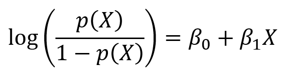

Logistic regression can be fit with the `glm()` function using the `binomial` family `glm` stands for Generalized Linear Models, and `binomial` implies that the y variable that we are predicting has 2 choices. After the model is fit, model predictions can be made with the `predict()` function just like we did with linear regressions.

Logistic regression does not require model residuals to be normally distributed or variance to be constant. AIC can be used for model comparison, i.e. to determine whether the inclusion of an additional independent variable constitutes a significantly improved model. McFadden’s Pseudo-$R^2$ can be used to assess fitness, where McFadden claims that a Pseudo-$R^2$ between 0.2 and 0.4 represents an “excellent fit”.

#### Which stocks have experienced a collapse?

What features of a stock make it more (or less) likely to experience a collapse? Let’s see if `FisheryType` from the `metadata` table is a significant explanatory variable for predicting the stock’s collapse. (Note that a chi-square test would also be an appropriate way to answer this question since we are comparing a categorical y variable against a single categorical x variable, but if we use a logistic regression model we could add more complexity with multiple x variables).

Since collapse is a yes/no, TRUE/FALSE, 1/0, binomial type of variable, we should use logistic regression.

```r
# Remove time series information and collapse data to "has this stock EVER collapsed?"
model_data = collapse %>%
  group_by(stockid) %>%
  summarize(ever_collapsed = any(current_collapse)) %>%
  ungroup() %>%
  left_join(metadata) %>%
  mutate(FisheryType = as.factor(FisheryType))
## Joining with `by = join_by(stockid)`

glimpse(model_data)
## Rows: 1,053
## Columns: 15
## $ stockid             <chr> "ACADRED2J3K", "ACADREDGOMGB", "ACADREDUT3", "ACMA…
## $ ever_collapsed      <lgl> TRUE, TRUE, TRUE, TRUE, TRUE, FALSE, FALSE, FALSE,…
## $ assessid            <chr> "DFO-ACADRED2J3K-1960-2010-WATSON", "NEFSC-ACADRED…
## $ stocklong           <chr> "Acadian redfish NAFO Division 2J3K", "Acadian red…
## $ assessyear          <chr> "1960-2010", "1912-2023", "1960-2010", "1989-2020"…
## $ scientificname      <chr> "Sebastes fasciatus", "Sebastes fasciatus", "Sebas…
## $ commonname          <chr> "Acadian redfish", "Acadian redfish", "Acadian red…
## $ areaname            <chr> "NAFO Division 2J3K", "Gulf of Maine / Georges Ban…
## $ managementauthority <chr> "Department of Fisheries and Oceans, Canada nation…
## $ assessorfull        <chr> "Department of Fisheries and Oceans", "Northeast F…
## $ region              <chr> "Canada East Coast", "US East Coast", "Canada East…
## $ FisheryType         <fct> Rockfish, Rockfish, Rockfish, Forage Fish, Other M…
## $ taxGroup            <chr> "sebastids", "sebastids", "sebastids", "carangids-…
## $ primary_FAOarea     <chr> "21", "21", "21", "41", "87", "57", "37", "27", "6…
## $ primary_country     <chr> "Russian Federation", "USA", "Canada", "Argentina"…

# Make sure I didn't add or subtract any rows:
length(unique(collapse$stockid))
## [1] 1053
dim(model_data)
## [1] 1053   15

# Run a logistic regression
model_l = glm(ever_collapsed ~ FisheryType, data = model_data, family = "binomial")
summary(model_l)
##
## Call:
## glm(formula = ever_collapsed ~ FisheryType, family = "binomial",
##     data = model_data)
##
## Coefficients:
##                                   Estimate Std. Error z value Pr(>|z|)
## (Intercept)                        -0.3909     0.1909  -2.047  0.04062 *
## FisheryTypeForage Fish              0.3771     0.2530   1.490  0.13619
## FisheryTypeGadids                   0.5262     0.2522   2.087  0.03692 *
## FisheryTypeInvertebrate            -0.4283     0.2407  -1.779  0.07519 .
## FisheryTypeOther Marine            -0.4331     0.2400  -1.804  0.07118 .
## FisheryTypeRockfish                 1.3382     0.3309   4.044 5.24e-05 ***
## FisheryTypeSharks Rays and Skates  -0.2684     0.2950  -0.910  0.36293
## FisheryTypeTuna and Marlin         -1.0755     0.4162  -2.584  0.00976 **
## ---
## Signif. codes:  0 '***' 0.001 '**' 0.01 '*' 0.05 '.' 0.1 ' ' 1
##
## (Dispersion parameter for binomial family taken to be 1)
##
##     Null deviance: 1416.4  on 1052  degrees of freedom
## Residual deviance: 1343.1  on 1045  degrees of freedom
## AIC: 1359.1
##
## Number of Fisher Scoring iterations: 4

# arrange fishery type alphabetically to see that intercept represents "Flatfish"
model_data %>% distinct(FisheryType) %>% arrange(FisheryType)
## # A tibble: 8 × 1
##   FisheryType
##   <fct>
## 1 Flatfish
## 2 Forage Fish
## 3 Gadids
## 4 Invertebrate
## 5 Other Marine
## 6 Rockfish
## 7 Sharks Rays and Skates
## 8 Tuna and Marlin
```

We have statistically significant coefficients for gadids, rockfish, and tuna and marlin, meaning these stocks are significantly more or less likely to collapse than the reference fishery type, which is flat fish. The coefficients for gadids, and rockfish are significant and positive, indicating that these stocks are more likely to collapse than flat fish. The coefficient for tuna and marlin is significant and negative (and the coefficients for invertebrates and “other marine” are almost significant and negative), indicating that these stocks are less likely to collapse than flat fish.

Figuring out the direction of an effect from the coefficients can be confusing, so the best way to interpret the model results is to create a prediction plot. To create the prediction plot, we use `predict.glm` and generate model predictions of a stock’s probability of ever experiencing a collapse for every fishery type in the dataset. We generate predictions with `type="response"` because we want our predictions to be on the scale of the response (y) variable. That means we want predictions between 0 and 1, using this equation:

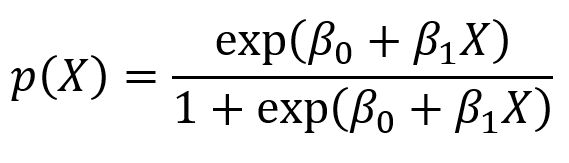

It is important to note that the default option for `predict.glm` is to generate predictions with `type="link"`, meaning that the predictions are generated on the scale of the linear predictors. In the case of a logistic regression, these predictions would be log-odds, and are calculated using this equation:

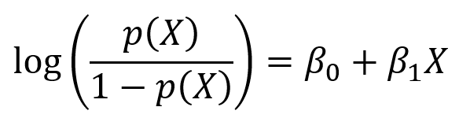

Since I want to plot the probability that a stock might experience a collapse for a given fishery type, I’ll use `type="response"`:

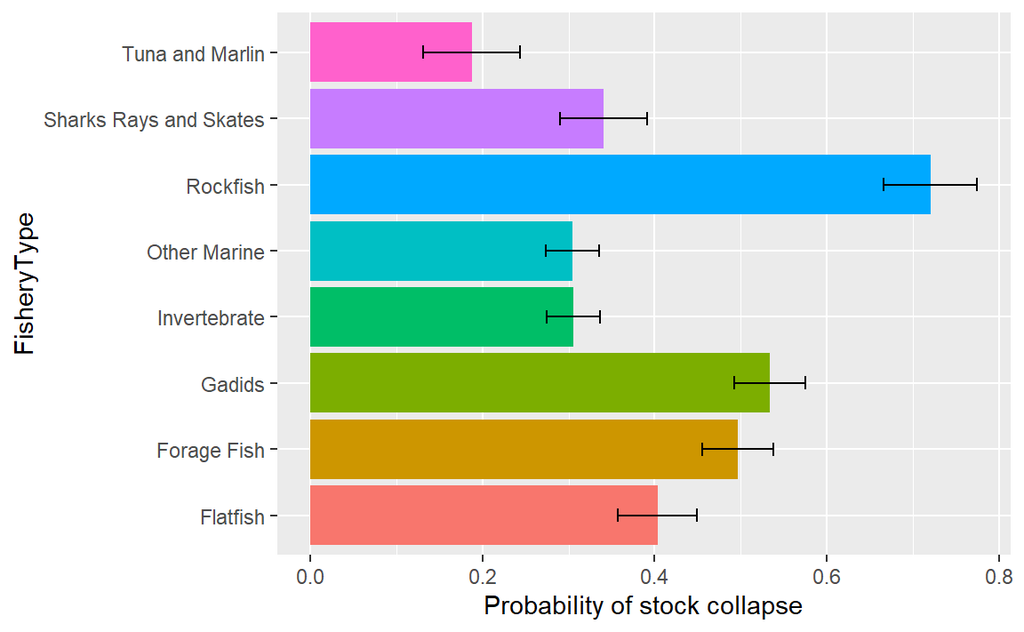

```r
# Make predictions on the probability of a stock collapse by fishery type
FisheryType = model_data %>% distinct(FisheryType)
# FisheryType = model_data %>% filter(primary_country=="Canada") %>% distinct(FisheryType)
model_l_predict = predict(model_l, newdata=FisheryType, type="response", se.fit=TRUE)

# Organize predictions into a tidy table
collapse_fishery_type_predictions = cbind(FisheryType, model_l_predict)

# Plot predictions and SE bars
ggplot(data=collapse_fishery_type_predictions) +
  geom_bar(aes(x=FisheryType, y=fit, fill=FisheryType),
           stat="identity", show.legend = FALSE) + # stat="count" is default (like histogram)
  geom_errorbar(aes(ymin=fit-se.fit, ymax=fit+se.fit, x=FisheryType), width=0.2) +
  coord_flip() +
  ylab("Probability of stock collapse")
```

```r
  # theme(legend.position = "none") # another way to hide a legend

# Calculate McFadden Pseudo-R^2: 0.2-0.4 = "Excellent fit"
# library(pscl)
# pscl::pR2(model_l)["McFadden"] # lousy fit
# model_l = glm(ever_collapsed ~ region + FisheryType, data = model_data, family = "binomial") # add region
# pscl::pR2(model_l)["McFadden"] # better fit
```

Logistic regression can be a good tool for any type of binomial analysis, including binomial categorical variables (like male/female, pass/fail, yes/no, true/false), probabilities (including demographic or state space transition probabilities), or presence / absence occurrence data. Use it. Love it.

### Poisson model

The poisson regression is usually the best choice for modeling count data: discrete data with non-negative integer values. The poisson model can also be applied to rate data, as in the count of an event per unit of time, space, etc. The divisor of your rate data (i.e. the amount of time, space, etc. sampled) will be treated as an “offset” variable in the model. In ecology, poisson regression is appropriate for counting individuals in a survey. For example, fish counts along a transect may need to be offset by transect length if the length isn’t standard in the survey. However, count of barnacles wouldn’t require an offset term if the same size quadrat is always used. Number of events can also be modeled with poisson regression, such as the number of rainy days per month, with an offset for the total number of days in the month.

There are two snags that you can run into with a poisson model: zero inflation and overdispersion.

Zero inflation can be problematic when there is an excessive amount of zeros in your count data. Often, the mechanisms that govern zero-counts may be different from the mechanisms that govern counts of >=1. For example, did you count zero of a certain fish species because the true number in that habitat is pretty low, or becuase you are in the completely wrong habitat? If you were an omniscient modeler, you would separate out the habitats that are “impossible” to find that species, and then run the model on the remaining data where it IS possible to find that species. However, it’s more likely that you don’t know enough to make that distinction (that’s why you are conducting these surveys!). So if you have zero-inflated data, you’ll have to consider removing the zeros and just explicitly modeling the positive count data, or designing a model that treats the zeros carefully (see below for more information).

Overdispersion occurs when the observed variance in your count data is much higher than the mean. After running a poisson model, you should test for overdispersion (I use `AER::dispersiontest()` from the Applied Econometrics with R `AER` package). If overdispersion is present, then you should switch to a different distributional family like a `quasipoisson` (where the variance is assumed to be a linear function of the mean) or a `negative binomial` (where the variance is assumed to be a quadratic function of the mean).

#### Model the period of time that a stock is collapsed

In the fisheries unit, I was hoping to demonstrate a poisson model where I predicted fish catch (i.e. the count of fish caught) with an offset for effort. CPUE (Catch Per Unit Effort) is a ubiquitous metric in fishery research. Unfortunately, there is very little effort data in the RAM dataset, so I decided to go a different route.

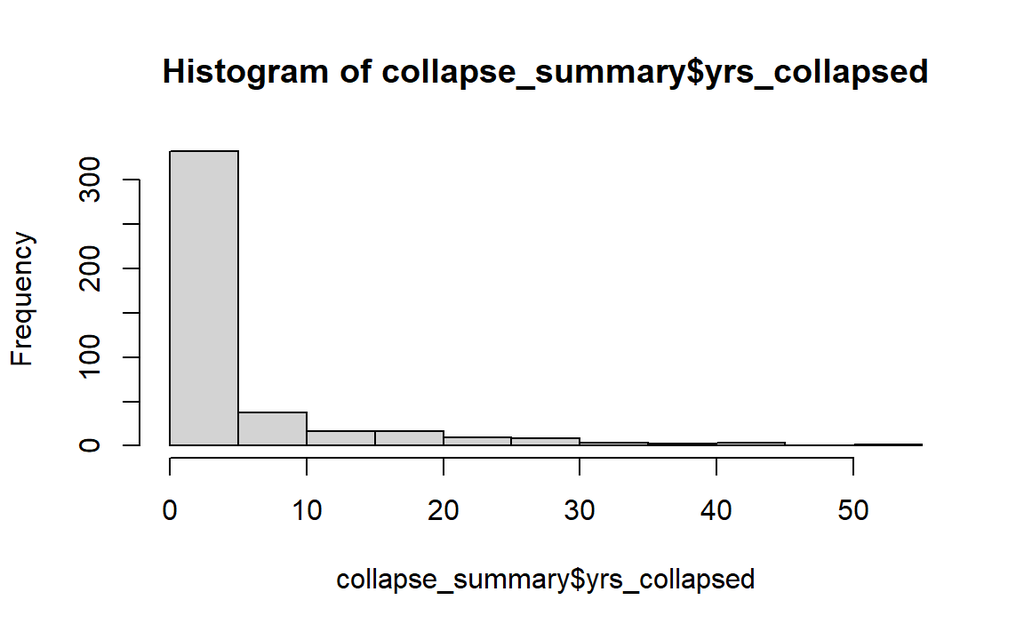

```r
# U is fishing pressure (often fishing mortalities) and B is biomass
# U / U_MSY is actual U relative to U at Max Sustainable Yield
# B / B_MSY is actual B relative to B at Max Sustainable Yield
# Calculate number of years a stock is overfished (U/U_MSY > 1)
# and number of years stock biomass is too low (B / B_MSY < 1)

tsmetrics %>% filter(tsshort == "UdivUmsypref")
##          tscategory      tsshort
## 1 FISHING MORTALITY UdivUmsypref
##                                                                                                                                                                tslong
## 1 General fishing mortality or exploitation rate time series preferentially relative to MSY-BRP, otherwise management target (UdivUmsytouse, otherwise UdivUmgttouse)
##    tsunitsshort   tsunitslong                   tsunique
## 1 dimensionless dimensionless UdivUmsypref-dimensionless
tsmetrics %>% filter(tsshort == "BdivBmsypref")
##      tscategory      tsshort
## 1 TOTAL BIOMASS BdivBmsypref
##                                                                                                                                 tslong
## 1 General biomass time series preferentially relative to MSY-BRP, otherwise management target (BdivBmsytouse, otherwise BdivBmgttouse)
##    tsunitsshort   tsunitslong                   tsunique
## 1 dimensionless dimensionless BdivBmsypref-dimensionless

u_summary = timeseries_values_views %>%
  #left_join(stock, by=c("stockid","stocklong")) %>%
  filter(!is.na(UdivUmsypref),
         !is.na(BdivBmsypref)) %>%
  group_by(stockid, stocklong) %>%
  summarize(yrs_data = n(),
            ratio_yrs_overfished = sum(UdivUmsypref > 1)/yrs_data,  # is ratio GREATER than 1? - high fishing rate
            ratio_yrs_low_stock = sum(BdivBmsypref < 1)/yrs_data) %>% # is ratio LESS than 1? - low stock
  select(-yrs_data) %>%
  ungroup() %>%
  left_join(metadata %>% select(stockid, FisheryType))
## `summarise()` has regrouped the output.
## Joining with `by = join_by(stockid)`
## ℹ Summaries were computed grouped by stockid and stocklong.
## ℹ Output is grouped by stockid.
## ℹ Use `summarise(.groups = "drop_last")` to silence this message.
## ℹ Use `summarise(.by = c(stockid, stocklong))` for per-operation grouping
##   (`?dplyr::dplyr_by`) instead.

head(u_summary)
## # A tibble: 6 × 5
##   stockid      stocklong    ratio_yrs_overfished ratio_yrs_low_stock FisheryType
##   <chr>        <chr>                       <dbl>               <dbl> <chr>
## 1 ACADREDGOMGB Acadian red…               0.482                0.464 Rockfish
## 2 ACMACKSARG   Argentine c…               0                    0     Forage Fish
## 3 ALBAIO       Albacore tu…               0.0588               0     Tuna and M…
## 4 ALBAMED      Albacore tu…               0.3                  0.325 Tuna and M…
## 5 ALBANATL     Albacore tu…               0.271                0.271 Tuna and M…
## 6 ALBANPAC     Albacore tu…               0                    0     Tuna and M…

# Count num years each stock is collapsed; join with counts of overfished-years and low-stock-years
collapse_summary = collapse %>%
  group_by(stockid) %>%
  summarize(yrs_data = n(),
            yrs_collapsed = sum(current_collapse)) %>%
  inner_join(u_summary, by="stockid") # only keep stocks that have collapse data AND u_summary data
glimpse(collapse_summary)
## Rows: 427
## Columns: 7
## $ stockid              <chr> "ACADREDGOMGB", "ACMACKSARG", "ALBAIO", "ALBAMED"…
## $ yrs_data             <int> 110, 29, 71, 71, 66, 85, 63, 69, 46, 70, 10, 17, …
## $ yrs_collapsed        <int> 39, 4, 0, 0, 0, 0, 0, 0, 0, 6, 0, 0, 1, 0, 5, 0, …
## $ stocklong            <chr> "Acadian redfish Gulf of Maine / Georges Bank", "…
## $ ratio_yrs_overfished <dbl> 0.48181818, 0.00000000, 0.05882353, 0.30000000, 0…
## $ ratio_yrs_low_stock  <dbl> 0.4636364, 0.0000000, 0.0000000, 0.3250000, 0.270…
## $ FisheryType          <chr> "Rockfish", "Forage Fish", "Tuna and Marlin", "Tu…

# Do we have zero-inflation?
hist(collapse_summary$yrs_collapsed)
```

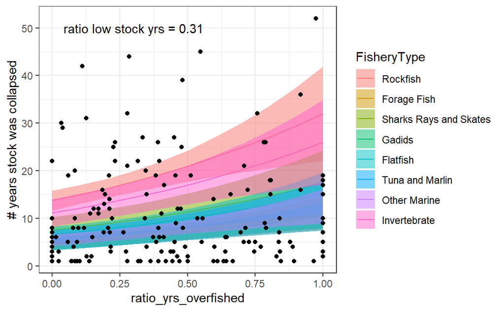

```r
table(collapse_summary$yrs_collapsed)
##
##   0   1   2   3   4   5   6   7   8   9  10  11  12  13  14  15  16  17  18  19
## 253  32   8  13  11  15   8   8   9   3   9   3   5   1   2   5   3   2   3   6
##  20  21  22  25  26  27  29  30  31  32  36  39  42  44  45  52
##   2   2   5   2   4   2   1   1   1   2   1   1   1   1   1   1

# Create a zero-truncated data set to demonstrate poisson model
collapse_summary_zero_trunc = collapse_summary %>% filter(yrs_collapsed>0)
summary(collapse_summary_zero_trunc)
##    stockid             yrs_data      yrs_collapsed    stocklong
##  Length:174         Min.   : 13.00   Min.   : 1.00   Length:174
##  Class :character   1st Qu.: 38.00   1st Qu.: 3.00   Class :character
##  Mode  :character   Median : 49.00   Median : 6.50   Mode  :character
##                     Mean   : 57.66   Mean   :10.17
##                     3rd Qu.: 70.00   3rd Qu.:15.00
##                     Max.   :132.00   Max.   :52.00
##  ratio_yrs_overfished ratio_yrs_low_stock FisheryType
##  Min.   :0.0000       Min.   :0.0000      Length:174
##  1st Qu.:0.0980       1st Qu.:0.1064      Class :character
##  Median :0.3772       Median :0.3091      Mode  :character
##  Mean   :0.3993       Mean   :0.3749
##  3rd Qu.:0.6552       3rd Qu.:0.5822
##  Max.   :1.0000       Max.   :1.0000

# Build poisson model
model_p = glm(yrs_collapsed ~ ratio_yrs_overfished + ratio_yrs_low_stock + FisheryType, offset(log(yrs_data)), data=collapse_summary_zero_trunc, family="poisson")
summary(model_p)
##
## Call:
## glm(formula = yrs_collapsed ~ ratio_yrs_overfished + ratio_yrs_low_stock +
##     FisheryType, family = "poisson", data = collapse_summary_zero_trunc,
##     weights = offset(log(yrs_data)))
##
## Coefficients:
##                                   Estimate Std. Error z value Pr(>|z|)
## (Intercept)                        1.83782    0.04163  44.144  < 2e-16 ***
## ratio_yrs_overfished               0.84534    0.06346  13.320  < 2e-16 ***
## ratio_yrs_low_stock                0.13065    0.05622   2.324  0.02012 *
## FisheryTypeForage Fish            -0.31456    0.05283  -5.954 2.61e-09 ***
## FisheryTypeGadids                 -0.36062    0.04687  -7.694 1.43e-14 ***
## FisheryTypeInvertebrate            0.53300    0.05154  10.342  < 2e-16 ***
## FisheryTypeOther Marine           -0.20052    0.04408  -4.550 5.38e-06 ***
## FisheryTypeRockfish                0.74188    0.04206  17.638  < 2e-16 ***
## FisheryTypeSharks Rays and Skates  0.13294    0.06643   2.001  0.04537 *
## FisheryTypeTuna and Marlin        -0.19265    0.06650  -2.897  0.00377 **
## ---
## Signif. codes:  0 '***' 0.001 '**' 0.01 '*' 0.05 '.' 0.1 ' ' 1
##
## (Dispersion parameter for poisson family taken to be 1)
##
##     Null deviance: 6285.3  on 173  degrees of freedom
## Residual deviance: 5084.0  on 164  degrees of freedom
## AIC: 7646.1
##
## Number of Fisher Scoring iterations: 6

# Do we have overdispersion?
# library(AER) # don't need to load library if using package::function() notation
AER::dispersiontest(model_p)$p.value < 0.05 # TRUE = overdispersed; FALSE = NOT overdispersed
## [1] TRUE

# Address overdispersion with a quasipoisson or negative binomial model
model_qp = glm(yrs_collapsed ~ ratio_yrs_low_stock + ratio_yrs_overfished + FisheryType, offset(log(yrs_data)), data=collapse_summary_zero_trunc, family="quasipoisson")
summary(model_qp)
##
## Call:
## glm(formula = yrs_collapsed ~ ratio_yrs_low_stock + ratio_yrs_overfished +
##     FisheryType, family = "quasipoisson", data = collapse_summary_zero_trunc,
##     weights = offset(log(yrs_data)))
##
## Coefficients:
##                                   Estimate Std. Error t value Pr(>|t|)
## (Intercept)                         1.8378     0.2434   7.552 2.84e-12 ***
## ratio_yrs_low_stock                 0.1307     0.3286   0.398  0.69146
## ratio_yrs_overfished                0.8453     0.3710   2.279  0.02398 *
## FisheryTypeForage Fish             -0.3146     0.3088  -1.019  0.30989
## FisheryTypeGadids                  -0.3606     0.2740  -1.316  0.18994
## FisheryTypeInvertebrate             0.5330     0.3013   1.769  0.07871 .
## FisheryTypeOther Marine            -0.2005     0.2576  -0.778  0.43752
## FisheryTypeRockfish                 0.7419     0.2459   3.017  0.00296 **
## FisheryTypeSharks Rays and Skates   0.1329     0.3883   0.342  0.73252
## FisheryTypeTuna and Marlin         -0.1926     0.3887  -0.496  0.62084
## ---
## Signif. codes:  0 '***' 0.001 '**' 0.01 '*' 0.05 '.' 0.1 ' ' 1
##
## (Dispersion parameter for quasipoisson family taken to be 34.17096)
##
##     Null deviance: 6285.3  on 173  degrees of freedom
## Residual deviance: 5084.0  on 164  degrees of freedom
## AIC: NA
##
## Number of Fisher Scoring iterations: 6

# we could dump ratio_yrs_low_stock, which was not significant
# model_qp2 = glm(yrs_collapsed ~ ratio_yrs_overfished + FisheryType, offset(log(yrs_data)), data=collapse_summary_zero_trunc, family="quasipoisson")
# summary(model_qp2)

# Make predictions on the time period a stock spends collapsed
# as a function of low stock year rates with overfishing rates set to the observed median
median_ratio_yrs_low_stock = median(collapse_summary_zero_trunc$ratio_yrs_low_stock)
newdata = expand.grid(FisheryType = unique(collapse_summary_zero_trunc$FisheryType),
                      ratio_yrs_overfished = seq(from=0,to=1,by=0.1),
                      ratio_yrs_low_stock = median_ratio_yrs_low_stock)

#newdata = data.frame(ratio_yrs_low_stock = seq(from=0,to=1,by=0.1),
#                     ratio_yrs_overfished = median(collapse_summary_zero_trunc$ratio_yrs_overfished))
model_qp_predict = predict(model_qp, type="response", newdata = newdata, se.fit=TRUE)

# Organize predictions into a tidy table
collapse_time_predictions = cbind(newdata, model_qp_predict)

# Plot predictions and SE ribbon
ggplot() +
  geom_line(aes(x=ratio_yrs_overfished, y=fit, color=FisheryType), data=collapse_time_predictions) +
  geom_ribbon( aes(x=ratio_yrs_overfished, ymin = fit-se.fit, ymax = fit+se.fit, fill=FisheryType), alpha = .5, data=collapse_time_predictions) +
  geom_point(aes(x=ratio_yrs_overfished, y=yrs_collapsed), data=collapse_summary_zero_trunc) +
  annotate("text", x=0.3, y=50, label= paste0("ratio low stock yrs = ", round(median_ratio_yrs_low_stock, 2))) +
  ylab("# years stock was collapsed") +
  # facet_wrap(~FisheryType) +
  theme_bw()
```

The count of years that a stock was in a collapsed state had many zeros, and the zero-inflation would make a problem for a poisson model fit. We dealt with this by removing the zeros, but we must keep in mind that this fundamentally changes the analysis to: “Out of the stocks that have experienced a collapse at some point, what drives the length of time they spend collapsed?”. This is still an interesting (and related question) but the results should be presented in the right context. We also found overdispersion in the data, which can lead to biased standard errors. We can address this by switching to a quasipoisson distribution.

The final `model_qp` shows that the ratio of years that a stock is overfished DOES significantly drive the time spent in the collapsed state, but the ratio of time that a stock’s biomass falls below $B_{MSY}$ is NOT a significant driver of the time spent in the collapsed state. Fishery Type is also a significant predictor of the number of years a stock is in the collapsed state. We plotted the quasipoisson model fit across the range of possible overfished time periods, while holding the ratio of time spent in the low biomass state constant at the observed median. The plot shows that the predicted time spent in the collapsed state goes from something like 5 to up to 30 years (i.e. for rockfish) as the ratio of time spent in the overfished state moves from 0 to 100% of the data collection period.

### Exercise 3.1

Try running a poisson model predicting the number of years that a stock is collapsed as a function of the ratio of time spent overfished and the ratio of time spent at low stock status. Leave out the fishery type. This time, only include data from the Atlantic Ocean. Test the poisson model to see if overdispersion is an issue. If it is a problem, refit the model as a quasipoisson. Do you think there is an advantage or a disadvantage to breaking the data into distinct regions?

### More Information

A good primer on logistic regression in R: https://afit-r.github.io/logistic_regression

More info on zero inflation in poisson models: You can formally check for zero-inflation with the `pscl::vuong()` test. To address zero-inflation, you have three options: 1) build a zero-truncated model, which means you remove the zeros from your data and run the model on your “presence” data only. This is a simple solution, but it throws away data, and may fundamentally change the question you are answering. 2) Build a two-part “hurdle” model where you model presence/absence with one model, and model non-zero counts with a second model; then present the results of both models together. 3) Build a mixture model that attempts to distinguish true zeros from false zeros. For more info on addressing zero inflation in R: https://fukamilab.github.io/BIO202/04-C-zero-data.html

### Acknowledgements

Logistic regression figure was pulled from Data Camp: https://www.datacamp.com/community/tutorials/logistic-regression-R